# Exercise Data ML Analysis

BODF

12/14/2018

# Summary

The goal in this analysis is to build an algorithm that can detect the difference between effective and ineffective excercise. The data analyzed here come from http://groupware.les.inf.puc-rio.br/har, and involve exercise data from six participants wearing three accelerometers. The participants were asked to excercise correctly (Class A) or incorrectly in various ways (Classes B thru E).

This report first splits the ‘training’ data into training and test sets, and it also imports the ‘test’ data as a validation set. The code of the report then reformats the data and excludes unnecessary variables before fitting a random forest to the training set data.

- Citation: The data are from this paper http://groupware.les.inf.puc-rio.br/public/papers/2013.Velloso.QAR-WLE.pdf
- Footnote: I used the post from Len Greski, one of the class mentors, to make my random forest model run in parallel, see here https://github.com/lgreski/datasciencectacontent/blob/master/markdown/pml-randomForestPerformance.md.

# Data formatting

The supplied data are of a rather raw format and need to be pre-processed. Here are some examples of problems addressed in code that can be found in the raw R markdown document (include = FALSE for most of my code).

- There are some variables of questionable worth to this analysis that should be ignored (user names, raw timestamps, dates, the first column being an index)
  - To be clear we want an algorithm that is generalizable. We could certainly fit every variable and get a great fit, but it wouldn’t be useful in addressing the goal of this project.
- Several numerical variables have empty data points. They are recorded as “”, NA, and “#DIV/0!”. My csv import pushes all the missing values to NA.
- Most of the variables have no missing values, but some variables are over 90% missing. These are likely not imputable and I removed them (see raw Rmd if interested).

```r
# Import the data and split the training data into train and test sets
setwd("~/Documents/Classes/DataSciCourse/FitnessData/")
training <- read.csv("pml-training.csv", na.strings = c("", " ", "#DIV/0!"))
validation <- read.csv("pml-testing.csv", na.strings = c("", " ", "#DIV/0!"))
set.seed(3232328)
trainIndex <- createDataPartition(training$classe, p = 0.75,list=FALSE)
testing <- training[-trainIndex,]
training <- training[trainIndex,]; rm(trainIndex)
```

Before fitting a model, we should consider how many values are highly correlated. (Highly correlated values could produce bias.) I made a function that captures all correlations above a particular cut off value, and have plotted the output below. As the cut off value increases, there is an exponential decrease in the fraction of correlations meeting the cut off. A cut off of 0.7 contains less than 2% of the data and I (somewhat arbitrarily) chose it as a cut off for removing values from further analysis.

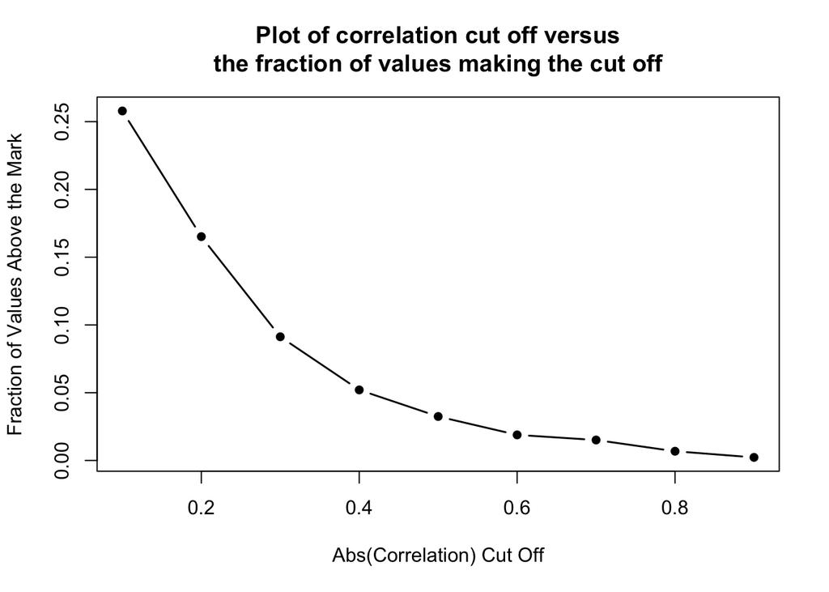

Based on a correlation cut-off of 0.7, there were 26 values that were highly correlated. In some of the underlying code, I removed a subset of these variables from the data and left their covariates behind, as listed here:

- total_accel_belt was used to represent accel_belt_x and y, roll_belt, yaw_belt, magnet_belt_x
- gyros_dumbbell_z for gyros_forearm_y and z
- magnet_arm_z for magnet_arm_y and accel_arm_z
- accel_arm_x for magnet_arm_x
- magnet_belt_z for magnet_belt_y
- magnet_dumbbell_y for gyros_belt_x
- accel_forearm_y for magnet_forearm_y
- accel_dumbell_x for pitch_dumbbell
- accel_dumbell_z for yaw_dumbbell
- total_accel_dumbbell for accel_dumbbell_y
- Footnote: I also considered using PCA to remove the correlated aspects of the data, but decided against it due to the non-normality and discontinuous nature of some of the data.

# Modeling

Because we are dealing with categorical outcomes, let’s try fitting a random forest (“rf”) to the data. This will produce a series of decision trees and make predictions based on the average of the trees.

For this particular fit, I used K-fold cross validation (5 fold) wherein the data are split into five groups, and fit five times. In each fitting step, one of the groups is chosen as the internal ‘testing’ group and this role is shifted to the next group with each fitting step. As an extra validation step, I also compare the fit to the test data that I set aside at the beginning of this analysis.

```r
# separate dependent and independent vars
x <- training[,-1]
y <- training[,1]

# set up parallel processing, this code fragment is from Len Greski's GitHub post
# see the footnote at the begining of the doc
cluster <- makeCluster(detectCores() - 1)
registerDoParallel(cluster)

# set up train control
control <- trainControl(method = 'cv', number = 5, allowParallel = TRUE)

# Fitting, takes less than six mins with 7 cores on MB pro
set.seed(33543)
mdlRfor <- train(x,y, method = 'rf', trControl = control)
stopCluster(cluster)
registerDoSEQ()

confusionMatrix.train(mdlRfor) # Give the prediction matrix
```

```
## Cross-Validated (5 fold) Confusion Matrix
##
## (entries are percentual average cell counts across resamples)
##
##           Reference
## Prediction    A    B    C    D    E
##          A 28.4  0.2  0.0  0.0  0.0
##          B  0.0 19.1  0.2  0.0  0.0
##          C  0.0  0.1 17.2  0.4  0.0
##          D  0.0  0.0  0.0 16.0  0.0
##          E  0.0  0.0  0.0  0.0 18.3
##
##  Accuracy (average) : 0.9906
```

As the confusion matrix above illustrates, the final model has a high in-sample accuracy of about 99%. This is similar to the out-of sample accuracy, seen in the confusion matrix for the test data set, below:

```r
confusionMatrix(predict(mdlRfor, testing), testing$classe)
```

```
## Confusion Matrix and Statistics
##
##           Reference
## Prediction    A    B    C    D    E
##          A 1393    7    0    0    0
##          B    1  940   14    0    0
##          C    0    2  840   20    0
##          D    0    0    1  784    1
##          E    1    0    0    0  900
##
## Overall Statistics
##
##                Accuracy : 0.9904
##                  95% CI : (0.9873, 0.9929)
##     No Information Rate : 0.2845
##     P-Value [Acc > NIR] : < 2.2e-16
##
##                   Kappa : 0.9879
##  Mcnemar's Test P-Value : NA
##
## Statistics by Class:
##
##                      Class: A Class: B Class: C Class: D Class: E
## Sensitivity            0.9986   0.9905   0.9825   0.9751   0.9989
## Specificity            0.9980   0.9962   0.9946   0.9995   0.9998
## Pos Pred Value         0.9950   0.9843   0.9745   0.9975   0.9989
## Neg Pred Value         0.9994   0.9977   0.9963   0.9951   0.9998
## Prevalence             0.2845   0.1935   0.1743   0.1639   0.1837
## Detection Rate         0.2841   0.1917   0.1713   0.1599   0.1835
## Detection Prevalence   0.2855   0.1947   0.1758   0.1603   0.1837
## Balanced Accuracy      0.9983   0.9934   0.9885   0.9873   0.9993
```

The validation data were not supplied with their actual ‘classe’ values, so it is unclear how accurate my model is on the validation data. Nonetheless, here are the predictions: B, A, B, A, A, E, D, B, A, A, B, C, B, A, E, E, A, B, B, B

# Conclusion

The prediction algorithm appears to work, as it is able to accurately detect the difference between five different classes of excercise.